# mdki-projektbesprechung

## MDKI Technische Aspekte (Gruppe 4)

### Zweite Sitzung: Besprechung der Projektideen

**Jula Lühring**

[figure not shown]

## Der Ablauf der heutigen Sitzung

1. Wiederholung: Organisatorisches
2. Wiederholung: Erwartungen und Bewertungskriterien
3. Refresher: Machine Learning

– Pause & Fragen –

5. Besprechung der Projektideen
6. Gruppenarbeit

# Organisatorisches

## Kursablauf

**1. Termin: 04.03.2026, 9 - 13 Uhr**

- Kurze Einleitung und Kennenlernen
- Gruppeneinteilungen

**2. Termin: 23.04.2026, 9 - 13 Uhr**

- Besprechung der Projektideen
- Klärung von Problemen und Fragen

**3. Termin: 17.06.2026, 9 - 13 Uhr**

- Abschlusspräsentationen

Sprechstunden-Termine zur begleitenden Projekt-Betreuung werden **nach Bedarf<sup>1</sup>** vereinbart!

<sup>1</sup> Melden Sie sich gerne: jula.luehring@uni-graz.at

# Erwartungen an Sie

Alle Infos finden Sie auch auf Moodle!

## Bewertungskriterien der Abschlusspräsentation (und Projekte)

1. **Motivation**
   - Klare Forschungsfrage oder Problembeschreibung
   - Inwiefern ist dies relevant?
   - Gibt es vorherige Forschungsarbeiten?
2. **Methoden- und Datenbeschreibung**
   - Woher stammen die Daten? Deskriptive Statistiken, Schritte zur Datenbereinigung
   - Welcher Machine Learning / KI-Ansatz wurde gewählt und wie steht er im Zusammenhang mit der Forschungsfrage?
   - Dokumentation und Begründung der Hyperparameter-Auswahl
3. **Analyse**
   - Kritische Beurteilung der Performance (Accuracy, F1, Silhouette score etc.)
   - Analyse der Ergebnisse zur Beantwortung der Frage
4. **Fazit**
   - Werden die Ergebnisse in Bezug zur Forschungsfrage gesetzt?
   - Welche Einschränkungen / potenziellen Probleme hat der Ansatz?

**Im Zweifel:** Fragen Sie gerne oder schauen Sie sich an, wie Forschende diese Aspekte in wissenschaftlichen Fachzeitschriften angehen.

## Angabe von Mitarbeit

Ähnlich zu CRediT (Contribution Roles Taxonomy; s. [Wiley](https://authors.wiley.com/author-resources/Journal-Authors/open-access/credit.html)):

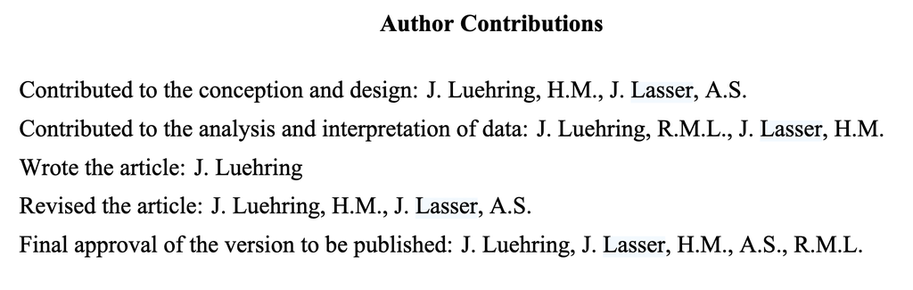

Hier könnte das so aussehen:

```
1. Konzeptualisierung der Fragestellung und Methodik
2. Datensammlung und/oder Bereinigung der Daten
3. Anwendung von Machine Learning
4. Evaluierung der Methode
5. Statistische Analysen
6. Vorbereitung der Abschlusspräsentation
```

# Refresher: Machine Learning

## Denken Sie an die Vorlesung:

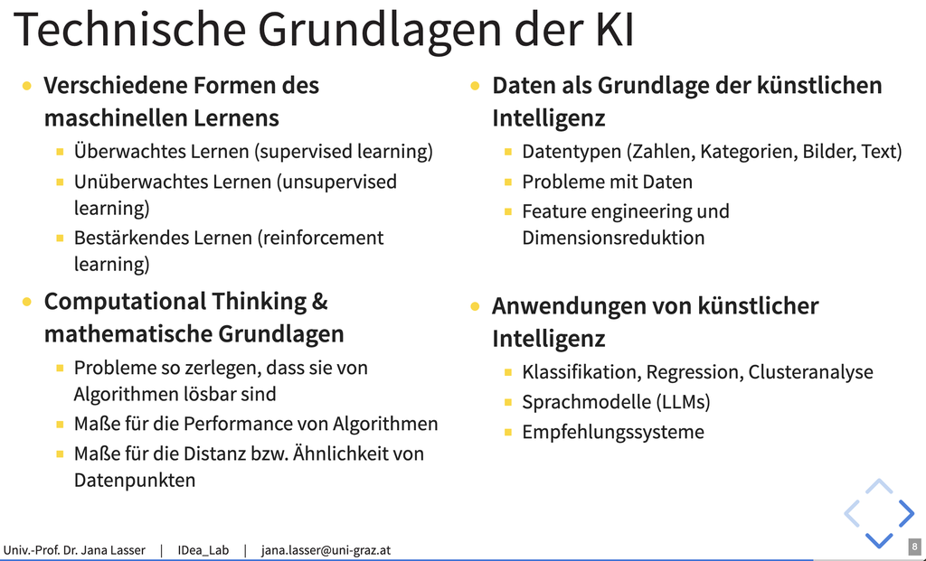

## Unsupervised vs Supervised Machine Learning

- Der große Unterschied: **Trainingsdaten!**
- Haben wir *Ground Truth*, also gelabelte Beispiele für das Training?

|  | **Supervised** | **Unsupervised** |
| --- | --- | --- |
| **Labels** | vorhanden | nicht vorhanden |
| **Ziel** | bekannte Muster lernen | unbekannte Muster finden |
| **Beispiel** | Spam-Filter | Themen in Nachrichten |

## Unüberwachtes Lernen / unsupervised learning

*Keine Ground Truth: das Modell findet selbst Struktur in den Daten*

**Clustering** = Gruppierung ähnlicher Beobachtungen

- k-Means: teilt Daten in $k$ Gruppen anhand von Distanz
- Hierarchisches Clustering: baut decision trees der Ähnlichkeiten
- Usw.

## Überwachtes Lernen / supervised learning

*Mit Ground Truth: das Modell lernt aus gelabelten Beispielen.*

- **Klassifikation**: Ausgabe ist eine Klasse (z.B. Spam / kein Spam)
  - Naive Bayes, decision tree, random forest, logistic regression, usw.
- **Regression**: Ausgabe ist ein kontinuierlicher Wert (z.B. Preis)
  - Decision tree, random forest, linear regression, usw.

> Entscheidend: die Qualität und Balance der Labels!

## Welcher Algorithmus?

- **No Free Lunch Theorem:** Kein Algorithmus ist universell am besten
- **Faustregel**: mit simplen Modellen und Hyperparametern starten, Komplexität bei Bedarf erhöhen und Ergebnisse systematisch evaluieren!

[figure not shown]

## Übliche Mischformen

- **semi-supervised learning**: wenige Labels, daher lernt das Modell von beidem
- **self-supervised**: das Modell erstellt eigene Label und lernt dann davon
- **transfer learning**: man nimmt ein vortrainiertes Modell, z.B. ein passendes BERT-Modell von huggingface.com

## Deep Learning und LLMs

- **Deep learning**: unstrukturierte Daten, gut für Bilder und Audio; braucht aber viele Daten, daher oft transfer learning
- **LLMs**: zero- oder few-shot learning (lokal z.B. mit Ollama)

## Wie viele Daten?

- **Faustregel**: circa 10× mehr Observationan als Attribute, aber idealerweise mehr.
  - Ansonsten: Komplexität des Modells, Performanz, usw.
  - Bei kleineren Datensätzen: simplere Modelle, Kross-Validation, usw.
- **Grundsätzlich**: ein guter Datensatz > der Algorithmus

*$\rightarrow$ Was macht einen guten Datensatz aus?*

## Trainingsdaten und Evaluierung

*Hinweis: Hierbei handelt es sich um die Trainingsphase, nicht um die Anwendung.*

**Overfitting erkennen & vermeiden**

- Train-Test-Split: 80 / 20
- Bei großer Datenmenge: Train-Validate-Test (70 / 10 / 20)

**Underfitting vermeiden**: komplexeres Modell wählen, mehr/bessere Daten, mehr Training

**Class Imbalance vermeiden**: unbedingt Klassenverteilung in Trainingsdaten prüfen!!

## Fehlermatrix & Evaluation

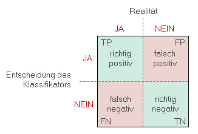

**Statistische Metriken:** Genauigkeit / Accuracy, Sensitivität / Recall, Spezifizität / Precision, F1-Wert

$\rightarrow$ *Die Wahl der Metrik hängt von den Erwartungen ab, s. Vorlesung zur Performance*<sup>1</sup>

[^1]: [janalasser.at/lectures/MC_KI/VO2_2_performance](https://janalasser.at/lectures/MC_KI/VO2_2_performance/#/2/2/1)

## Area under the curve

Vergleich von kontinuierlicher Vorhersage gegen Klassen

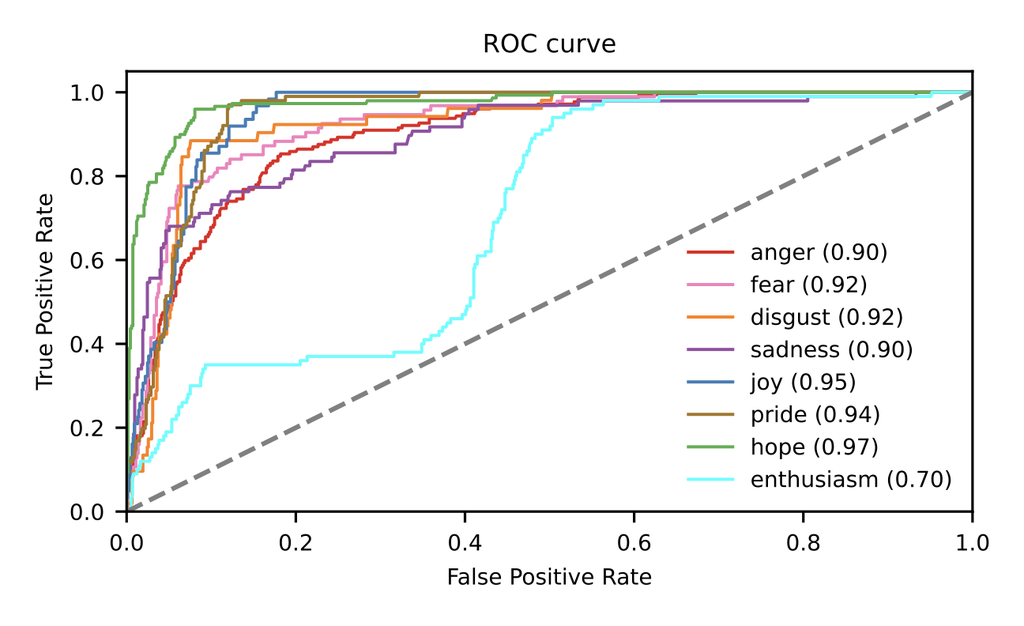

Luehring et al., [2025](https://doi.org/10.31234/osf.io/cemw7_v1)

$\rightarrow$ In so einer Grafik kann man auch die Performanz von verschiedenen *Modellen* oder *Hyperparametern* vergleichen

## Modellfehler

*Hinweis: Bias und Varianz beschreiben das Modell, nicht die Daten.*

[figure not shown]

**Bias**: systematische Abweichung des Modells von den wahren Werten

**Varianz**: starke Streuung des Modells für ähnliche Werte

## Data & code sharing: best practices

**Daten**: Ggf. anonymisieren und auf europäischen Servern bereitstellen (z.B. OSF)

> Zook et al. ([2017](https://doi.org/10.1371/journal.pcbi.1005399)): Ten rules for responsible big data research

**Code**: GitHub oder GitLab für version control, Google Colab zum direkten Kollaborieren an Skripten oder auch ein OSF-repository mit Daten und Code

> GitHub Education (mit Copilot) oder Claude Code (in der Konsole)

## Klassische Pipeline

1. Haben wir gelabelte Daten, wie viele und wie gut ist die Qualität?
2. Testen verschiedener Ansätze und Hyperparameter
3. Auswertung dessen, was am besten klappt – mit Diskussion der Implikationen und Fehler

# Offene Fragen?

Dann auf zu Moodle!

# 30 Minuten Pause

Danach: kurze Updates aus Ihren Projekten!

# Besprechung der Fragen

# Besprechung der Projektideen

Sie sind dran!

## Wie geht’s weiter bis zur nächsten Einheit?

1. Ggf. Überarbeitung von Konzeptualisierung
2. Deskriptive Auswertung & Bereinigung der Daten
3. Anwendung Ihrer gewählten Methode & Auswertung dessen
4. Analyse zur Beantwortung der Fragestellung
5. Vorbereitung der Abschlusspräsentation

Machen Sie einen Termin mit mir aus zur Zwischenbesprechung!

# Gruppenarbeit

Falls nicht: vielen Dank und einen schönen Tag!

[figure not shown]